# Projekt - Airline Loyalty Program Promotion and Beyond

Manca Prošek, Tristan Dragan, Patricija Jaklič

2026-08-14

# Branje podatkov

## 1. Customer Flight Activity.csv

Osnovne lastnosti podatkov (Customer Flight Activity): Št. vrstic: 392,936 Št. stolpcev: 8 Ni manjkajočih podatkov/vrstic Vse spremenljivke so numerične Vse spremenljivke razen Loyalty Number in Month so asimetrične v desno.

```r
pregled_CFA <- create_report(Customer_Flight_Activity)
```

```
##
##
## processing file: report.rmd
```

[output not shown]

[output not shown]

[output not shown]

[output not shown]

[output not shown]

[output not shown]

[output not shown]

```
## output file: /Users/manca/Documents/Faks/Poslovna statistika/Projekt/Poslovna stat/report.knit.md
```

[output not shown]

```
##
## Output created: report.html
```

## 2. Customer Loyalty History.csv

Osnovne lastnosti podatkov (Customer Loyalty History): Št. vrstic: 16,737 Št. stolpcev: 16 Št. manjkajočih podatkov: 33,578 Št. popolnih vrstic: 1,540 Št. numeričnih spremenljivk: 7 Št. opisnih spremenljivk: 9 Spremenljivke z manjkajočimi vrednostmi so: Salary (25.32%), Cancellation Month (87.65%) in Cancellation Year (87.65%).

```r
pregled_CLH <- create_report(Customer_Loyalty_History)
```

```
##
##
## processing file: report.rmd
```

[output not shown]

[output not shown]

[output not shown]

[output not shown]

[output not shown]

[output not shown]

[output not shown]

[output not shown]

```
## output file: /Users/manca/Documents/Faks/Poslovna statistika/Projekt/Poslovna stat/report.knit.md
```

[output not shown]

```
##
## Output created: report.html
```

# Viri

## Customer churn—————————————–

1. članek/vir (osnove customer churn): Customer Churn Prediction: A Systematic Review of Recent Advances, Trends, and Challenges in Machine Learning and Deep Learning *Imani, M., Joudaki, M., Beikmohammadi, A., & Arabnia, H. R. (2025)* Link: [1.clanek] (www.mdpi.com/2504-4990/7/3/105?utm_source=chatgpt.com)
2. članek/vir: An asymmetrical approach to understanding con gurations of customer loyalty in the airline industry *Catherine Prenticea, Sandra Maria Correia Loureirob* Link: [2.clanek] (https://www.sciencedirect.com/science/article/pii/S0969698917301789?fr=RR-1&ref=cra_js_challenge)
3. članek/vir: Key drivers of passenger loyalty: A case of Frankfurt–Istanbul flights. (2016). *Journal of Air Transport Management* Link: [3.clanek] (https://www.sciencedirect.com/science/article/pii/S0969699715300120?utm_source=chatgpt.com)
4. članek/vir: Frequent flyer programs in academic studies: A literature review of research progress since 2000. (2025). *Journal of Air Transport Management.* Link: [4.clanek] (https://www.sciencedirect.com/science/article/pii/S0969699725001838?utm_source=chatgpt.com)
5. članek/vir: In Pursuit of Enhanced Customer Retention Management: Review, Key Issues, and Future Directions *Ascarza, E., Neslin, S. A., Netzer, O., et al. (2018)* Link: [5.clanek] (https://business.columbia.edu/sites/default/files-efs/pubfiles/25780/ascarza_et_al_choice_symposium.pdf)
6. članek/vir: Beyond Accuracy: What Data Quality Means to Data Consumers. (2015) *Richard Y. Wang & Diane M. Strong* Link: [6.clanek] (https://www.tandfonline.com/doi/abs/10.1080/07421222.1996.11518099) -> Kakovost podatkov
7. članek/vir: Data Fusion. ACM Computing Surveys, 41(1), Article 1. *Bleiholder, J., & Naumann, F. (2008)* Link: [7.clanek] (https://dl.acm.org/doi/abs/10.1145/1456650.1456651) -> Strategija razreševanja konfliktov in utemeljitev, zakaj brez dodatnih kriterijev izbira ni upravičena.
8. članek/vir:Data Cleaning of Data Streams *Restat, V., Rodenhausen, N., Antonin, C., & Störl, U. (2025).* Link: [8.clanek] (https://arxiv.org/abs/2507.20839)
9. članek/vir: Data Cleaning: Problems and Current Approaches *Rahm, E., & Do, H. H. (2000).* Link: [9.clanek] (https://www.researchgate.net/publication/220282831_Data_Cleaning_Problems_and_Current_Approaches)

# Magisterska naloga-Janez-Bijec——————————–

Vir/pomoč: Magistrska naloga: Janez Bijec: Statistični kazalniki kakovosti in učinkoviotsti oskrbe pacientov s koronarno boleznijo

Izpiski: - Kdaj so podatki kakovostni? Kadar so “fit for purpose” - ocenjevanje kakovosti podatkov prilagodit vsaki analizi posebaj glede na njene zahteve - Avtor v svoji analizi uporabi dva načina: - 1. Na podlagi modela ocenjevanja in terminologije dimenzij kakovosti (prilagojen za elektronske zdravstvene podatke) (*skladnost*, *celovitost*, *prepričljivost - verjetnost*) - 2. konceptualni način

## 1.NAČIN——————————————–

### MODEL OCENJEVANJA IN TERMINOLOGIJE DIMENZIJ KAKOVOSTI

1. SKLADNOST - ali so podatki skladni z definiranimi formati, ustrezajo pričakovani obliki in opisom v metapodatkih (poddimenzije: vrednostna skladnost, relacijska skladnost, računska skladnost)
- VREDNOSTNA skladnost: spol ima samo dve vrednosti, starost nima negativnih vrednosti,…
- RELACIJSKA skladnost: omogočanje relacije med tabelami v bazi podatkov
- RAČUNSKA pravilnost izpeljanih spremenljivk
2. CELOVITOST - dimenzija kakovosti, ki ocenjuje prisotnost oz. odsotnost (tudi frekvenco podatkov) ne da bi se ozirala na vrednosti, ki jih podatki zavzemajo. Ta dimenzija kakovosti nima poddimenzij.
3. PREPRIČLJIVOST - VERJETNOST: dimenzija kakovosti, ki osredotoča na same vrednosti, ki jih zavzemajo (imajo podatki) in poskuša odgovoriti na vprašanje, kako vrednosti podatkov opisujejo realno stanje, koliko jim je mogoče zaupati.

Poddimenzije: - UNIKATNA PREPRIČLJIVOST (angl. Uniquness plausibility) podvajanje podatkov, tam kjer niso smiselni (npr. en identifikator pacienta je povezan z dvema spoloma ali dvema različnima glavnima diagnozama za isto hospitalizacijo) - NEČASOVNA PREPRIČLJIVOST (angl. Atemporal plausibility) Povezana z oceno koliko se vrednosti in porazdelitve vrednosti skladajo glede na neko splošno vedenje ali glede na nek zunanju standard. (npr. telesne višine pacientov se porazdeljuje normalno s povprečjem 170 cim in standardnim odklonom 15cm) - ČASOVNA PREPLIČLJIVOST (angl. Temporal plausibility) Smiselnost in pravilnost spreminjanja ali ohranjanja vrednosti spremenljivk glede na čas (npr. ali je telesna višina pri večini pacientov v adolescenci smiselno naraščala, odraslega pacienta pa ostala nespremenljena)

## Ocenjevanje dimenzij kakovosti—————–

### 1. VERTIFIKACIJA (angl. Vertification)

Temelji na podatkih kot takih na smiselnosti na ujemanju z omejitvami in strukturo na ekspertnih mnenjih in logičnih povezavah.

### 2. VALIDACIJA (angl. Validation)

Temelji na preverjanju podatkov glede na nek zunanji vir, ki lahko predstavlja zlati standard.

## 2.NAČIN-KONCEPTUALNI——————————————–

Avtor poskuša odkriti določene sistemske pomanjklivosti v podatkih. Ideja Weng in Casey -> predpostavka merljivih konceptov v medicini

# OCENA-KAKOVOSTI-PODATKOV—————————–

Kakovost podatkov bomo preverili na podlagi šestih najbolj uporabljenih dimenzij od petnajstih, ki so navedeni v (6.članku). Odločili smo se za šest dimenzij na podlagi literature in praks.

Glavne dimenzije ocenjevanja kvalitete podatkov, ki jih bomo upoštevali pri naši analizi so: 1.Natančnost ali točnost  
2.Celovitost  
3.Doslednost  
4.Pravočasnost  
5.Veljavnost  
6.Enoličnost

## 1.Natančnost podatkov

“Natančnost podatkov pomeni, kako dobro se informacije ujemajo z dejstvi iz resničnega sveta. Natančnost podatkov se osredotoča na pravilnost in zanesljivost podatkov ter zagotavlja, da ti ne vsebujejo napak, ki bi nastale zaradi nepravilnega vnosa ali pomanjkljive obdelave. Primarni cilj zagotavljanja točnosti podatkov je prepoznavanje in odpravljanje napak v podatkovnih vrednostih, kot so napake pri prepisovanju, podvojeni vnosi in napačne vrednosti. Točnost podatkov se dosega z uporabo: – čiščenja podatkov za prepoznavanje in odpravljanje napak ter neskladnosti v naborih podatkov, kot so odstranjevanje podvojenih zapisov, popravljanje tipkarskih napak in standardizacija podatkov; – preverjanja veljavnosti podatkov s pomočjo vnaprej določenih pravil ali algoritmov za odkrivanje napak, neskladnosti in netočnosti v podatkih med postopkom vnosa ali naknadno; – profiliranja podatkov za prepoznavanje vzorcev, trendov in nepravilnosti v naborih podatkov, ki lahko kažejo na netočnosti ali neskladnosti.”

Za naše podatke nimamo zunanjih referenčnih virov s katerim bi lahko naredili neposredno primerjavo podatkov za preverjanje točnosti podatkov, ker nimamo neodvisnega vira točnosti podatkov ne moremo empirično dokazati. Zato bomo v nadaljevanju preverjali logična pravila in potencialne napačne oz ekstremne vrednosti.

```r
summary(Customer_Flight_Activity)
```

```
##  Loyalty Number        Year          Month        Total Flights
##  Min.   :100018   Min.   :2017   Min.   : 1.000   Min.   : 0.000
##  1st Qu.:327688   1st Qu.:2017   1st Qu.: 4.000   1st Qu.: 0.000
##  Median :551833   Median :2018   Median : 7.000   Median : 0.000
##  Mean   :550528   Mean   :2018   Mean   : 6.514   Mean   : 1.295
##  3rd Qu.:772194   3rd Qu.:2018   3rd Qu.:10.000   3rd Qu.: 2.000
##  Max.   :999986   Max.   :2018   Max.   :12.000   Max.   :28.000
##     Distance     Points Accumulated Points Redeemed Dollar Cost Points Redeemed
##  Min.   :    0   Min.   :     0     Min.   :  0.0   Min.   :  0.000
##  1st Qu.:    0   1st Qu.:     0     1st Qu.:  0.0   1st Qu.:  0.000
##  Median :    0   Median :     0     Median :  0.0   Median :  0.000
##  Mean   : 1941   Mean   :  2027     Mean   : 31.3   Mean   :  5.636
##  3rd Qu.: 3018   3rd Qu.:  3039     3rd Qu.:  0.0   3rd Qu.:  0.000
##  Max.   :67284   Max.   :100926     Max.   :876.0   Max.   :158.000
```

```r
summary(Customer_Loyalty_History)
```

```
##  Loyalty Number     Country            Province             City
##  Min.   :100018   Length:16737       Length:16737       Length:16737
##  1st Qu.:326603   Class :character   Class :character   Class :character
##  Median :550434   Mode  :character   Mode  :character   Mode  :character
##  Mean   :549736
##  3rd Qu.:772019
##  Max.   :999986
##
##  Postal Code           Gender           Education             Salary
##  Length:16737       Length:16737       Length:16737       Min.   :-58486
##  Class :character   Class :character   Class :character   1st Qu.: 59246
##  Mode  :character   Mode  :character   Mode  :character   Median : 73455
##                                                           Mean   : 79246
##                                                           3rd Qu.: 88518
##                                                           Max.   :407228
##                                                           NA's   :4238
##  Marital Status     Loyalty Card            CLV        Enrollment Type
##  Length:16737       Length:16737       Min.   : 1898   Length:16737
##  Class :character   Class :character   1st Qu.: 3981   Class :character
##  Mode  :character   Mode  :character   Median : 5780   Mode  :character
##                                        Mean   : 7989
##                                        3rd Qu.: 8941
##                                        Max.   :83325
##
##  Enrollment Year Enrollment Month Cancellation Year Cancellation Month
##  Min.   :2012    Min.   : 1.000   Min.   :2013      Min.   : 1.000
##  1st Qu.:2014    1st Qu.: 4.000   1st Qu.:2016      1st Qu.: 4.000
##  Median :2015    Median : 7.000   Median :2017      Median : 7.000
##  Mean   :2015    Mean   : 6.669   Mean   :2017      Mean   : 6.963
##  3rd Qu.:2017    3rd Qu.:10.000   3rd Qu.:2018      3rd Qu.:10.000
##  Max.   :2018    Max.   :12.000   Max.   :2018      Max.   :12.000
##                                   NA's   :14670     NA's   :14670
```

Pri spremenljivki ‘Salary’ smo zaznali negativne vrednosti. Pri plači (‘Salary’) pričakujemo samo pozitivne vrednosti zato bomo v nadaljevanju po principu čiščenja in ocenjevanja kakovosti podatkov obravnavali te vrednosti

## 2.Celovitost

Podatki so celoviti, če so prisotni vsi potrebni podatki ali so določene vrednosti manjkajoče. Celovitost ne pomeni le odsotnosti praznih polj, temveč tudi, ali zbrani podatki zadostno pokrivajo vse pomembne vidike analiziranega pojava.

```r
map_dbl(Customer_Flight_Activity, ~mean(is.na(.))) %>% sort(decreasing = TRUE)
```

```
##              Loyalty Number                        Year
##                           0                           0
##                       Month               Total Flights
##                           0                           0
##                    Distance          Points Accumulated
##                           0                           0
##             Points Redeemed Dollar Cost Points Redeemed
##                           0                           0
```

```r
map_dbl(Customer_Loyalty_History, ~mean(is.na(.))) %>% sort(decreasing = TRUE)
```

```
##  Cancellation Year Cancellation Month             Salary     Loyalty Number
##          0.8765012          0.8765012          0.2532114          0.0000000
##            Country           Province               City        Postal Code
##          0.0000000          0.0000000          0.0000000          0.0000000
##             Gender          Education     Marital Status       Loyalty Card
##          0.0000000          0.0000000          0.0000000          0.0000000
##                CLV    Enrollment Type    Enrollment Year   Enrollment Month
##          0.0000000          0.0000000          0.0000000          0.0000000
```

V izpisanih tabelah lahko vidimo, da podatki o letih nimajo manjkajočih vrednosti, prav tako bi iz podakih podatkov rekli, da so podane vse potrebne vrednosti.

V tabeli podatkov o članih programa pa opazimo, da imamo manjkajoče vrednosti pri spremenljivki ‘Salary’ in pa seveda pri spremenljivkama ‘Cancellation Year’ in ‘Cancellation Month’, ki pa niso manjkajoči podatki, saj so to še aktualni člani in podatka enostavno ni. Tudi pri tem naboru podatkov bi za dane stolpce rekli, da so podatki dovolj obsežni in nam podajajo dovolj informacij za celovitost.

Vrnimo se sedaj k spremenljivki o plačah, kjer nam manjka 25% vrednosti. Trend manjkajočnosti si tu želimo bolj natančno pogledati, če uspemo najti kakšen vzorec.

```r
# Vzorec manjkajočih vrednosti
Customer_Loyalty_History %>%
  filter(is.na(Salary)) %>%
  count(Gender)
```

| Gender | n |
| --- | --- |
| Female | 2084 |
| Male | 2154 |

```r
Customer_Loyalty_History %>%
  filter(is.na(Salary)) %>%
  count(`Loyalty Card`)
```

| Loyalty Card | n |
| --- | --- |
| Aurora | 794 |
| Nova | 1332 |
| Star | 2112 |

```r
Customer_Loyalty_History %>%
  filter(is.na(Salary)) %>%
  count(`Marital Status`)
```

| Marital Status | n |
| --- | --- |
| Divorced | 376 |
| Married | 1436 |
| Single | 2426 |

```r
# Plače manjkajo vsem, ki imajo izobrazbo "College" !!!
Customer_Loyalty_History %>%
  filter(is.na(Salary)) %>%
  count(Education)
```

| Education | n |
| --- | --- |
| College | 4238 |

```r
Customer_Loyalty_History %>%
  count(Education)
```

| Education | n |
| --- | --- |
| Bachelor | 10475 |
| College | 4238 |
| Doctor | 734 |
| High School or Below | 782 |
| Master | 508 |

Našli smo vzorec manjkajočnosti, in sicer podatek o plači je manjkajoč pri vseh, ki imajo nivo izobrazbe enak “College”.

## 3.Doslednost

Doslednost podatkov pa predstavlja njihovo ujemanje med različnimi viri, sistemi ali časovnimi odbobji. Podatki so dosledni, kadar ni protislovij in kadar so medsebojno logično skladni.

```r
# Ali imajo vsi poleti veljavno stranko v loyalty tabeli?
anti_join(Customer_Flight_Activity, Customer_Loyalty_History, by = "Loyalty Number") %>% nrow()
```

```
## [1] 0
```

```r
# nesmiselne vrednosti
summary(Customer_Flight_Activity$`Total Flights`)
```

```
##    Min. 1st Qu.  Median    Mean 3rd Qu.    Max.
##   0.000   0.000   0.000   1.295   2.000  28.000
```

```r
summary(Customer_Flight_Activity$Distance)
```

```
##    Min. 1st Qu.  Median    Mean 3rd Qu.    Max.
##       0       0       0    1941    3018   67284
```

```r
Customer_Flight_Activity %>% filter(`Total Flights` == 0 & Distance > 0)
```

| Loyalty Number | Year | Month | Total Flights | Distance | Points Accumulated | Points Redeemed | Dollar Cost Points Redeemed |
| --- | --- | --- | --- | --- | --- | --- | --- |

```r
Customer_Flight_Activity %>% filter(`Total Flights` > 0 & Distance == 0)
```

| Loyalty Number | Year | Month | Total Flights | Distance | Points Accumulated | Points Redeemed | Dollar Cost Points Redeemed |
| --- | --- | --- | --- | --- | --- | --- | --- |

```r
summary(Customer_Loyalty_History$Salary)
```

```
##    Min. 1st Qu.  Median    Mean 3rd Qu.    Max.    NA's
##  -58486   59246   73455   79246   88518  407228    4238
```

```r
Customer_Loyalty_History %>% filter(Salary < 0)
```

| Loyalty Number | Country | Province | City | Postal Code | Gender | Education | Salary | Marital Status | Loyalty Card | CLV | Enrollment Type | Enrollment Year | Enrollment Month | Cancellation Year | Cancellation Month |
| --- | --- | --- | --- | --- | --- | --- | --- | --- | --- | --- | --- | --- | --- | --- | --- |
| 542976 | Canada | Quebec | Montreal | H2Y 4R4 | Male | High School or Below | -49830 | Divorced | Star | 24127.50 | 2018 Promotion | 2018 | 3 | NA | NA |
| 959977 | Canada | British Columbia | Vancouver | V5R 1W3 | Female | Bachelor | -12497 | Married | Aurora | 9453.00 | 2018 Promotion | 2018 | 3 | NA | NA |
| 232755 | Canada | British Columbia | Vancouver | V1E 4R6 | Female | Bachelor | -46683 | Single | Nova | 4787.81 | 2018 Promotion | 2018 | 3 | NA | NA |
| 525245 | Canada | British Columbia | Victoria | V10 6T5 | Male | Bachelor | -45962 | Married | Star | 2402.33 | 2018 Promotion | 2018 | 3 | NA | NA |
| 603070 | Canada | British Columbia | West Vancouver | V6V 8Z3 | Female | Bachelor | -19325 | Single | Star | 2893.74 | 2018 Promotion | 2018 | 3 | NA | NA |
| 491242 | Canada | British Columbia | Dawson Creek | U5I 4F1 | Male | Bachelor | -43234 | Married | Star | 7597.91 | 2018 Promotion | 2018 | 3 | NA | NA |
| 115505 | Canada | Newfoundland | St. John's | A1C 6H9 | Male | Bachelor | -10605 | Married | Nova | 5860.17 | 2018 Promotion | 2018 | 4 | NA | NA |
| 430398 | Canada | Newfoundland | St. John's | A1C 6H9 | Male | Bachelor | -17534 | Married | Nova | 49423.80 | 2018 Promotion | 2018 | 3 | NA | NA |
| 152016 | Canada | Ontario | Toronto | P1J 8T7 | Female | Bachelor | -58486 | Married | Aurora | 5067.21 | 2018 Promotion | 2018 | 2 | NA | NA |
| 194065 | Canada | Ontario | Sudbury | M5V 1G5 | Female | Bachelor | -31911 | Married | Nova | 2888.85 | 2018 Promotion | 2018 | 2 | NA | NA |

[output cut: 10 more lines]

Pogledali smo še, če imajo vsi podatki o letih veljavno številko kartice zvestove v podatkih o kartičarjih in pa če obstajajo, kakšne nesmiselne vrednosti. Opazili smo negativne plače, ki jih bomo obravnavali pod točko 5, razen tega pa podatki delujejo dosledni.

## 4.Pravočasnost

Pravočasnost nam pove, ali so podatki na voljo dovolj hitro glede na potrebe uporabe in ali odražajo trenutno stanje. Pri analizi odtoka strank to pomeni, da podatki o vedenju strank ne smejo biti zastareli, saj se preference in vedenje hitro spreminjajo.

Ker analiziramo bazo starih podatkov in imamo pomanjkljive informacije o pridobitvi podatkvo in prav tako o pridobivanju, bomo to točko spustili. Omenili smo jo, ker je izredno pomembna pri vseh analizah kakovosti podatkov in je ne smemo pozabiti. Za potrebe naše naloge bomo rekli, da so podatki pravočasni in da dobro odražajo trenutno stanje.

## 5.Veljavnost

Kot je bilo že ugotovljeno zgoraj smo opazili negativne vrednosti pri spremenljivki ‘Salary’, kar ni pričakovano. Te vrednosti smo zaznali kot neveljavne. V nadaljevanju bomo preverili ali obstaja kakšen vzorec negativnih vrednosti in se na podlagi podrobnejšega pregleda podatkov odločili kaj bomo z njimi naredili.

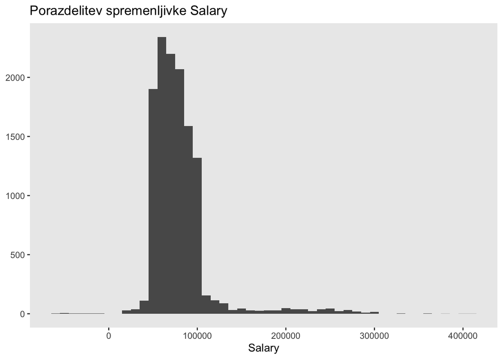

```r
ggplot(Customer_Loyalty_History, aes(x = Salary)) +
  geom_histogram(binwidth=10000) +
  theme(panel.grid = element_blank()) +
  labs(
    title = "Porazdelitev spremenljivke Salary",
    x = "Salary",
    y = NULL
  )
```

```r
Customer_Loyalty_History %>%
  filter(Salary < 0) %>%
  summarise(
    n = n(),
    min_salary = min(Salary),
    max_salary = max(Salary)
  )
```

| n | min_salary | max_salary |
| --- | --- | --- |
| 20 | -58486 | -9081 |

```r
# delež
mean(Customer_Loyalty_History$Salary < 0, na.rm = TRUE)
```

```
## [1] 0.001600128
```

```r
# Vzorec negativnih vrednosti
Customer_Loyalty_History %>%
  filter(Salary < 0) %>%
  count(Gender)
```

| Gender | n |
| --- | --- |
| Female | 10 |
| Male | 10 |

```r
Customer_Loyalty_History %>%
  filter(Salary < 0) %>%
  count(Education)
```

| Education | n |
| --- | --- |
| Bachelor | 19 |
| High School or Below | 1 |

```r
Customer_Loyalty_History %>%
  filter(Salary < 0) %>%
  count(`Loyalty Card`)
```

| Loyalty Card | n |
| --- | --- |
| Aurora | 3 |
| Nova | 9 |
| Star | 8 |

```r
Customer_Loyalty_History %>%
  filter(Salary < 0) %>%
  summary()
```

```
##  Loyalty Number     Country            Province             City
##  Min.   :115505   Length:20          Length:20          Length:20
##  1st Qu.:238155   Class :character   Class :character   Class :character
##  Median :433242   Mode  :character   Mode  :character   Mode  :character
##  Mean   :468737
##  3rd Qu.:634693
##  Max.   :959977
##
##  Postal Code           Gender           Education             Salary
##  Length:20          Length:20          Length:20          Min.   :-58486
##  Class :character   Class :character   Class :character   1st Qu.:-46840
##  Mode  :character   Mode  :character   Mode  :character   Median :-41368
##                                                           Mean   :-35538
##                                                           3rd Qu.:-19330
##                                                           Max.   : -9081
##
##  Marital Status     Loyalty Card            CLV        Enrollment Type
##  Length:20          Length:20          Min.   : 2402   Length:20
##  Class :character   Class :character   1st Qu.: 4788   Class :character
##  Mode  :character   Mode  :character   Median : 6406   Mode  :character
##                                        Mean   : 9919
##                                        3rd Qu.:10334
##                                        Max.   :49424
##
##  Enrollment Year Enrollment Month Cancellation Year Cancellation Month
##  Min.   :2018    Min.   :2.00     Min.   :2018      Min.   : 8
##  1st Qu.:2018    1st Qu.:2.75     1st Qu.:2018      1st Qu.: 9
##  Median :2018    Median :3.00     Median :2018      Median :10
##  Mean   :2018    Mean   :3.05     Mean   :2018      Mean   :10
##  3rd Qu.:2018    3rd Qu.:4.00     3rd Qu.:2018      3rd Qu.:11
##  Max.   :2018    Max.   :4.00     Max.   :2018      Max.   :12
##                                   NA's   :18        NA's   :18
```

```r
# Opcija
Customer_Loyalty_History <- Customer_Loyalty_History %>%
  mutate(
    Salary = if_else(Salary < 0, NA_real_, Salary)
  )
```

## 6.Enoličnost

Enoličnost podatkov pomeni odsotnost podvojenih zapisov. To pomeni, da mora biti vsaka entiteta v podatkovni bazi zastopana samo enkrat. Enoličnost je pomembna za pravilno združevanje in preprečevanje dvojnega štetja pri analizah.

```r
# Dvojniki po ključu
Customer_Loyalty_History %>% count(`Loyalty Number`) %>% filter(n > 1) # naj bo prazno - 1 vrstica na stranko
```

| Loyalty Number | n |
| --- | --- |

```r
Customer_Flight_Activity  %>% count(`Loyalty Number`, Year, Month) %>% filter(n > 1) # naj bo prazno
```

| Loyalty Number | Year | Month | n |
| --- | --- | --- | --- |
| 101902 | 2017 | 1 | 2 |
| 101902 | 2017 | 2 | 2 |
| 101902 | 2017 | 3 | 2 |
| 101902 | 2017 | 4 | 2 |
| 101902 | 2017 | 5 | 2 |
| 101902 | 2017 | 6 | 2 |
| 101902 | 2017 | 7 | 2 |
| 101902 | 2017 | 8 | 2 |
| 101902 | 2017 | 9 | 2 |
| 101902 | 2017 | 10 | 2 |

[output cut: 3837 more lines]

V zgornjem izpisu vidimo, da dvojnih vnosov o strankah ni, je pa kar veliko dvojnih vnosov v tabeli z leti. Če pogledamo dvojne vnose bolj natančno, opazimo, da imamo dve vrsti. Imamo dvojne vnose, ki so popolni dvojniki in imamo vnose, kjer so številka kartice zvestobe, leto in mesec enaki, ostali podatki pa so si med seboj različni. To sta dva problema, ki ju bomo obravnavali ločeno.

```r
## Podvojene vrstice v Customer_Flight_Activity
key_cols <- c("Loyalty Number", "Year", "Month")

# Za vsako skupino preveri velikost skupine in št. dejansko različnih vrstic znotraj nje
key_dup_summary <- Customer_Flight_Activity %>%
  group_by(across(all_of(key_cols))) %>%
  summarise(
    group_size        = n(),
    n_distinct_rows    = n_distinct(pick(everything())),
    .groups = "drop"
  ) %>%
  filter(group_size > 1)

# Ključi, kjer je skupina POPOLN dvojnik
full_dup_keys <- key_dup_summary %>%
  filter(n_distinct_rows == 1) %>%
  select(all_of(key_cols))

# Ključi, kjer skupina NI popoln dvojnik
partial_dup_keys <- key_dup_summary %>%
  filter(n_distinct_rows > 1) %>%
  select(all_of(key_cols))

nrow(full_dup_keys)
```

```
## [1] 1904
```

```r
nrow(partial_dup_keys)
```

```
## [1] 1943
```

```r
# Vpogled v primer nepopolnih dvojnikov
Customer_Flight_Activity %>%
  semi_join(partial_dup_keys, by = key_cols) %>%
  arrange(`Loyalty Number`, Year, Month) %>%
  head(10)
```

| Loyalty Number | Year | Month | Total Flights | Distance | Points Accumulated | Points Redeemed | Dollar Cost Points Redeemed |
| --- | --- | --- | --- | --- | --- | --- | --- |
| 101902 | 2017 | 4 | 1 | 667 | 667 | 0 | 0 |
| 101902 | 2017 | 4 | 1 | 2499 | 2499 | 488 | 88 |
| 101902 | 2017 | 5 | 3 | 7263 | 7263 | 0 | 0 |
| 101902 | 2017 | 5 | 2 | 3762 | 3762 | 0 | 0 |
| 101902 | 2017 | 6 | 3 | 4971 | 4971 | 0 | 0 |
| 101902 | 2017 | 6 | 3 | 5763 | 5763 | 0 | 0 |
| 101902 | 2017 | 8 | 5 | 3825 | 3825 | 0 | 0 |
| 101902 | 2017 | 8 | 4 | 8952 | 8952 | 0 | 0 |
| 101902 | 2017 | 9 | 2 | 3734 | 3734 | 0 | 0 |
| 101902 | 2017 | 9 | 1 | 2187 | 2187 | 0 | 0 |

- Obravnava popolnih dvojnikov - literatura

V viru 9 (Rahm in Do, 2000, Data Cleaning: Problems and Current Approaches) avtorja navajata, da odprava dvojnikov poteka v dveh korakih. Najprej identifikacija, ki smo jo že naredili, nato pa združitev oziroma odstranitev podvojenih zapisov. Ker imamo v našem primeru opravka s popolnimi dvojniki, kjer se vse vrednosti atributov ujemajo, med njimi ni nobenih protislovij ali manjkajočih informacij, ki bi jih bilo treba uskladiti. Zato lahko brez izgube podatkovne vsebine eno od kopij enostavno odstranimo, s čimer preprečimo dvojno štetje strank v nadaljnjih analizah, hkrati pa ohranimo celovitost in konsistentnost podatkovne baze.

- Obravnava nepopolnih dvojnikov - literatura

V viru 7 (Bleiholder & Naumann, 2008, ACM Computing Surveys, “Data Fusion”), ki govori o usklajevanju nasprotujočih si vrednosti, obstaja uveljavljena klasifikacija strategij, ki ločuje tri pristope:

- Conflict-resolving (razreševanje konflikta), kjer si izbereš eno vrednost na podlagi nekega kriterija: zanesljivosti vira, časovne novosti zapisa, večinskega glasovanja med več viri, ali domenskega znanja.
- Conflict-avoiding (izogibanje), kjer uporabiš pravilo (npr. vedno vzemi maksimum, minimum, povprečje).
- Conflict-ignoring (nerazreševanje), kjer se konflikta sploh ne poskuša razrešiti, temveč se pusti nerazrešen ali označi kot neznan.

Prvi dve zgornji strategiji razreševanja potrebujeta vsaj neko dodatno informacijo, na podlagi katere bi se odločili, katera vrednost je pravilnejša. To bi bil lahko podatek o viru, časovni žig vnosa podatkov, nek drug dodatek vir in podobno. Ker pa mi poleg podatkov nimamo drugega in so si nekatere naše vrednosti nasprotujoče (število letov in prepotovana razdalja v teh primerih nista pozitivno povezana), bi bila izbira ene od privih dveh rešitev zgolj ugibanje. To tudi Rahm & Do (2000) in Restat et al. (2025) izpostavita kot problem, da brez dodatnih pravil ali človeške presoje se kontradiktornega zapisa ne da zanesljivo razrešiti.

Zato je tudi v literaturi v takšnih primerih priznana pot nerazreševanja, saj namesto, da se izmislimo, katera vrednost je prava, oba zapisa označimo kot manjkajoč podatek. S tem ne vnašamo umetne pristranskosti v podatke, ohranjamo transparentnos in če bi bilo takih podatkov veliko, jih lahko obravnavamo kot manjkajoče vrednosti. Je pa pomembno dodatki, da je delež nepopolnih dvojnikov majhen in ne vpliva na rezultate naših nadaljnih analiz.

Kljub temu podatke sčistimo kot smo se s pomočjo literature odločili.

```r
# Nepopolni dvojniki = odstranimo vse
# Popolni dvojniki = odstranimo odvečne kopije

Customer_Flight_Activity_Clean <- Customer_Flight_Activity %>%
  anti_join(partial_dup_keys, by = key_cols) %>%
  distinct()

# Poročilo o čiščenju
n_total            <- nrow(Customer_Flight_Activity)
n_removed_partial  <- Customer_Flight_Activity %>% semi_join(partial_dup_keys, by = key_cols) %>% nrow()
n_removed_full_dup <- n_total - n_removed_partial - nrow(Customer_Flight_Activity_Clean)

cat("Vrstic prej:", n_total, "\n")
```

```
## Vrstic prej: 392936
```

```r
cat("Odstranjenih (nepopolni dvojniki - vse vrstice skupine):", n_removed_partial, "\n")
```

```
## Odstranjenih (nepopolni dvojniki - vse vrstice skupine): 3894
```

```r
cat("Odstranjenih (odvečne kopije popolnih dvojnikov):", n_removed_full_dup, "\n")
```

```
## Odstranjenih (odvečne kopije popolnih dvojnikov): 1920
```

```r
cat("Vrstic po čiščenju:", nrow(Customer_Flight_Activity_Clean), "\n")
```

```
## Vrstic po čiščenju: 387122
```

```r
# Kontrola = noben ključ naj se več ne podvaja
Customer_Flight_Activity_Clean %>% count(across(all_of(key_cols))) %>% filter(n > 1)
```

| Loyalty Number | Year | Month | n |
| --- | --- | --- | --- |

## Agregacija - Manca (če bi se slučajno rabili)

```r
## 3.2 Agregacija po stranki (na podlagi Customer_Flight_Activity_Clean)
## -------------------------------------------------------------------------

Customer_Activity <- Customer_Flight_Activity_Clean %>%
  group_by(`Loyalty Number`) %>%
  summarise(
    total_flights_sum    = sum(`Total Flights`, na.rm = TRUE),
    total_distance       = sum(Distance, na.rm = TRUE),
    points_accumulated   = sum(`Points Accumulated`, na.rm = TRUE),
    points_redeemed      = sum(`Points Redeemed`, na.rm = TRUE),
    dollar_cost_redeemed = sum(`Dollar Cost Points Redeemed`, na.rm = TRUE),
    active_months        = n_distinct(paste(Year, Month)),
    .groups = "drop"
  ) %>%
  mutate(
    redemption_rate       = if_else(points_accumulated > 0,
                                     points_redeemed / points_accumulated, 0),
    avg_flights_per_month = total_flights_sum / active_months
  )

df <- Customer_Loyalty_History %>%
  left_join(Customer_Activity, by = "Loyalty Number") %>%
  mutate(
    is_promo_2018 = `Enrollment Type` == "2018 Promotion",
    churned = !is.na(`Cancellation Year`)
  )

glimpse(df)
```

```
## Rows: 16,737
## Columns: 26
## $ `Loyalty Number`      <dbl> 480934, 549612, 429460, 608370, 530508, 193662, …
## $ Country               <chr> "Canada", "Canada", "Canada", "Canada", "Canada"…
## $ Province              <chr> "Ontario", "Alberta", "British Columbia", "Ontar…
## $ City                  <chr> "Toronto", "Edmonton", "Vancouver", "Toronto", "…
## $ `Postal Code`         <chr> "M2Z 4K1", "T3G 6Y6", "V6E 3D9", "P1W 1K4", "J8Y…
## $ Gender                <chr> "Female", "Male", "Male", "Male", "Male", "Male"…
## $ Education             <chr> "Bachelor", "College", "College", "College", "Ba…
## $ Salary                <dbl> 83236, NA, NA, NA, 103495, 51124, NA, 100159, 10…
## $ `Marital Status`      <chr> "Married", "Divorced", "Single", "Single", "Marr…
## $ `Loyalty Card`        <chr> "Star", "Star", "Star", "Star", "Star", "Star", …
## $ CLV                   <dbl> 3839.14, 3839.61, 3839.75, 3839.75, 3842.79, 384…
## $ `Enrollment Type`     <chr> "Standard", "Standard", "Standard", "Standard", …
## $ `Enrollment Year`     <dbl> 2016, 2016, 2014, 2013, 2014, 2012, 2014, 2016, …
## $ `Enrollment Month`    <dbl> 2, 3, 7, 2, 10, 5, 6, 12, 5, 10, 3, 6, 1, 10, 11…
## $ `Cancellation Year`   <dbl> NA, NA, 2018, NA, NA, NA, NA, NA, NA, NA, NA, NA…
## $ `Cancellation Month`  <dbl> NA, NA, 1, NA, NA, NA, NA, NA, NA, NA, NA, NA, N…
## $ total_flights_sum     <dbl> 37, 58, 18, 35, 37, 0, 40, 41, 27, 44, 51, 31, 2…
## $ total_distance        <dbl> 54525, 77487, 24803, 48432, 55515, 0, 61007, 728…
## $ points_accumulated    <dbl> 54525, 77487, 24803, 48432, 55515, 0, 61007, 728…
## $ points_redeemed       <dbl> 1418, 1971, 374, 1291, 0, 0, 1583, 733, 1516, 16…
## $ dollar_cost_redeemed  <dbl> 256, 356, 67, 233, 0, 0, 285, 132, 274, 303, 90,…
## $ active_months         <int> 24, 24, 24, 24, 24, 4, 24, 24, 24, 24, 24, 24, 2…
## $ redemption_rate       <dbl> 0.026006419, 0.025436525, 0.015078821, 0.0266559…
## $ avg_flights_per_month <dbl> 1.5416667, 2.4166667, 0.7500000, 1.4583333, 1.54…
## $ is_promo_2018         <lgl> FALSE, FALSE, FALSE, FALSE, FALSE, FALSE, FALSE,…
## $ churned               <lgl> FALSE, FALSE, TRUE, FALSE, FALSE, FALSE, FALSE, …
```

# (Manca) Razumeti dejavnike, ki vplivajo na vključenost v program zvestobe, in analizirati učinkovitost promocijske kampanje

## Učinkovitost 2018 promocije

```r
## -------------------------------------------------------------------------
## 4. UČINKOVITOST 2018 PROMOCIJE (primerjava skupin)
## -------------------------------------------------------------------------

# Opisna statistika po skupinah
df %>%
  group_by(`Enrollment Type`) %>%
  summarise(
    n = n(),
    povp_flights   = mean(total_flights_sum, na.rm = TRUE),
    povp_distance  = mean(total_distance, na.rm = TRUE),
    povp_CLV       = mean(CLV, na.rm = TRUE),
    povp_accumulated = mean(points_accumulated, na.rm = TRUE),
    povp_redeemed     = mean(points_redeemed, na.rm = TRUE),
    povp_redemption_rate = mean(redemption_rate, na.rm = TRUE),
    povp_dollar_redeemed = mean(dollar_cost_redeemed, na.rm = TRUE),
    churn_rate     = mean(churned, na.rm = TRUE)
  )
```

| Enrollment Type | n | povp_flights | povp_distance | povp_CLV | povp_accumulated | povp_redeemed | povp_redemption_rate | povp_dollar_redeemed | churn_rate |
| --- | --- | --- | --- | --- | --- | --- | --- | --- | --- |
| 2018 Promotion | 971 | 45.84758 | 68826.98 | 8046.511 | 103240.48 | 382.9990 | 0.004270479 | 68.96087 | 0.1184346 |
| Standard | 15766 | 28.97558 | 43437.28 | 7985.348 | 43437.28 | 744.7892 | 0.016731675 | 134.08271 | 0.1238107 |

```r
# Statistični test: CLV med Standard in 2018 Promotion (Wilcoxon, ker CLV ni nujno normalno porazdeljen)
wilcox.test(CLV ~ `Enrollment Type`, data = df)
```

```
##
##  Wilcoxon rank sum test with continuity correction
##
## data:  CLV by Enrollment Type
## W = 7683302, p-value = 0.8432
## alternative hypothesis: true location shift is not equal to 0
```

```r
# t-test za primerjavo povprečnega števila poletov
t.test(total_flights_sum ~ `Enrollment Type`, data = df)
```

```
##
##  Welch Two Sample t-test
##
## data:  total_flights_sum by Enrollment Type
## t = 24.987, df = 1042.6, p-value < 0.00000000000000022
## alternative hypothesis: true difference in means between group 2018 Promotion and group Standard is not equal to 0
## 95 percent confidence interval:
##  15.54703 18.19698
## sample estimates:
## mean in group 2018 Promotion       mean in group Standard
##                     45.84758                     28.97558
```

```r
# Chi-kvadrat: ali je tip kartice povezan z enrollment type?
chisq.test(table(df$`Enrollment Type`, df$`Loyalty Card`))
```

```
##
##  Pearson's Chi-squared test
##
## data:  table(df$`Enrollment Type`, df$`Loyalty Card`)
## X-squared = 0.68438, df = 2, p-value = 0.7102
```

```r
# Testi razlik med skupinama
wilcox.test(points_accumulated ~ `Enrollment Type`, data = df)
```

```
##
##  Wilcoxon rank sum test with continuity correction
##
## data:  points_accumulated by Enrollment Type
## W = 13176777, p-value < 0.00000000000000022
## alternative hypothesis: true location shift is not equal to 0
```

```r
wilcox.test(points_redeemed ~ `Enrollment Type`, data = df)
```

```
##
##  Wilcoxon rank sum test with continuity correction
##
## data:  points_redeemed by Enrollment Type
## W = 5434755, p-value < 0.00000000000000022
## alternative hypothesis: true location shift is not equal to 0
```

```r
wilcox.test(redemption_rate ~ `Enrollment Type`, data = df)
```

```
##
##  Wilcoxon rank sum test with continuity correction
##
## data:  redemption_rate by Enrollment Type
## W = 4248464, p-value < 0.00000000000000022
## alternative hypothesis: true location shift is not equal to 0
```

Na prvi pogled nam opisna statistika pokaže, da je promocija iz leta 2018 privabila 971 novih članov, ki so v obstoju naročnine leteli v povprečju kar 45-krat, medtem ko so normalne stranke letele le 29-krat v povprečju. Zelo hitro je jasno, da je promocija pripeljala stranke, ki so bolj pogosti uporabniki letalskih družb, kot standardno pridobljeni kartičarji.

Testi za primerjavo skupin po načinu vpisa (standardno ali promocijsko) kažejo naslednje rezultate. Stranke, ki so se vključile preko promocije, so v opazovanjem obdobju v povprečju opravile skoraj 17 letov več od standardno vpisanih strank. Ta razlika je statistično visoko značilna, saj Welchov t-test vrne rezultate t = 24.987 in p-value < 2.2e-16. Povprečni vrednosti vidni v tabeli pa sta za promocijsko skupino 45.8 in za standardno skupino 28.9.

Po drugi strani pa se CLV (customer lifetime value) med skupinama praktično ne razlikuje, saj so rezultati Wilcoxonovega testa W = 7683302 in p-value = 0.8432. Promocija torej ni pritegnila strank z višjo dolgoročno vrednostjo, temveč zgolj bolj aktivne letalce.

Na nadaljnih testih vidimo, da je zboranje in koriščenje točk visoko značilno med skupinama, vendar pa nam samo ta rezultat ne pove, katera skupina je bistveno boljša. Zato se obrnemo na tabelo s primerjavo, kjer opazimo, da medtem ko promocijski člani zberejo bistveno več točk zvestobe, so standardno včlanjeni člani tisti, ki jih več porabijo. Redemption rate je v povprečju pri standardnih članih 1.7%, medtem ko je pri promocijskih le 0.4%.

Zato je zanimivo, da je promocija privabila stranke, ki letijo veliko, se pa ne ozirajo dosti na koriščenje ugodnosti, ki jih program nudi. Potrebna bi bila nadaljna obravnava po plačilnem razredu in izobrazbi, vendar sklep je, da stranke, ki veliko letijo nimajo finančnih zadržkov in jim tako točke zvestobe niso pomemben del programa. Morda so jim bolj važne druge ugodnosti, ki jih program zvestobe nudi, vendar teh podatkov pa žal nimamo.

Tip kartice zvestobe (Star/Nova/Aurora) pa ni statistično povezan s tipom vpisa, saj je Chi test vrnil rezultete X-squared = 0.68438 in p-value = 0.7102. Promocija torej ni bila bolj privlačna za določen segment kartic.

Pomembna opomba je, da ker gre za opazovalne podatke, višja aktivnost promocijske skupine ne pomeni nujno, da je promocija vzročno povečala angažiranost. Enako verjeten scenarij je samoselekcija, in sicer da so se bolj pogosti letalci raje odločili za vključitev preko promocije. Za bolj zanesljiv vzročni zaključek bi bilo treba primerjati angažiranost istih strank pred in po vpisu.

Primerjaj v tabeli iz poglavja 4: pri Standard skupini je povp_distance = 43.437 in povp_accumulated = 43.437 — popolnoma identično. Pri 2018 Promotion skupini pa je povp_distance = 68.827, povp_accumulated = 103.240, kar je natanko 1,5-kratnik. To ni naključje — nakazuje, da imajo promocijske stranke 1,5× množitelj točk na prevoženi km, standardne pa 1×. To je pomembna ugotovitev za tvojo nalogo “učinkovitost promocije”: pomeni, da promocijska kampanja verjetno ni bila zgolj marketinška (privabi nove člane), ampak je vključevala tudi strukturno bonus stopnjo nabiranja točk kot del ponudbe. To delno pojasni, zakaj promocijski člani nabirajo tako veliko več točk — ne le zaradi več letov, temveč tudi zaradi ugodnejšega razmerja točk/km. Priporočam, da to eksplicitno preveriš in izpostaviš:

```r
df %>%
  group_by(`Enrollment Type`) %>%
  summarise(tocke_na_km = sum(points_accumulated, na.rm = TRUE) / sum(total_distance, na.rm = TRUE))
```

| Enrollment Type | tocke_na_km |
| --- | --- |
| 2018 Promotion | 1.5 |
| Standard | 1.0 |

To bi lepo dopolnilo tvoj odstavek o tem, zakaj promocijski člani “zberejo bistveno več točk, a jih manj unovčijo” — zdaj imaš razlago tudi za zakaj zbirajo toliko več, ne le hipotezo o vedenju.

Manjkajo: - pogled tudi po izobrazbi in prihodku.

## Faktorji, ki vplivajo na engagement

```r
## -------------------------------------------------------------------------
## 5. FAKTORJI, KI VPLIVAJO NA ENGAGEMENT
## -------------------------------------------------------------------------

# Korelacija numeričnih spremenljivk z engagementom
df %>%
  select(Salary, CLV, total_flights_sum, total_distance, redemption_rate) %>%
  cor(use = "pairwise.complete.obs")
```

```
##                         Salary          CLV total_flights_sum total_distance
## Salary             1.000000000 -0.021016986      -0.001653776   -0.002261964
## CLV               -0.021016986  1.000000000      -0.006916046   -0.005992790
## total_flights_sum -0.001653776 -0.006916046       1.000000000    0.967839881
## total_distance    -0.002261964 -0.005992790       0.967839881    1.000000000
## redemption_rate    0.009981686 -0.006658419       0.015660545   -0.004235114
##                   redemption_rate
## Salary                0.009981686
## CLV                  -0.006658419
## total_flights_sum     0.015660545
## total_distance       -0.004235114
## redemption_rate       1.000000000
```

```r
library(reshape2)  # za melt(), ali uporabi tidyr::pivot_longer
```

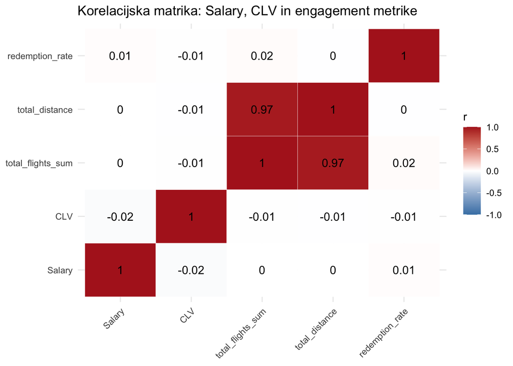

```r
cor_matrix <- df %>%
  select(Salary, CLV, total_flights_sum, total_distance, redemption_rate) %>%
  cor(use = "pairwise.complete.obs")

cor_long <- melt(cor_matrix)

ggplot(cor_long, aes(x = Var1, y = Var2, fill = value)) +
  geom_tile(color = "white") +
  geom_text(aes(label = round(value, 2)), color = "black", size = 4) +
  scale_fill_gradient2(low = "steelblue", mid = "white", high = "firebrick",
                        midpoint = 0, limits = c(-1, 1), name = "r") +
  labs(title = "Korelacijska matrika: Salary, CLV in engagement metrike",
       x = NULL, y = NULL) +
  theme_minimal() +
  theme(axis.text.x = element_text(angle = 45, hjust = 1))
```

```r
# Linearni model: kaj napoveduje število poletov?
model <- lm(total_flights_sum ~ Salary + Education + `Marital Status` +
              Gender + `Loyalty Card` + is_promo_2018, data = df)
summary(model)
```

```
##
## Call:
## lm(formula = total_flights_sum ~ Salary + Education + `Marital Status` +
##     Gender + `Loyalty Card` + is_promo_2018, data = df)
##
## Residuals:
##     Min      1Q  Median      3Q     Max
## -47.131 -11.438   3.879  11.925  58.121
##
## Coefficients:
##                                   Estimate   Std. Error t value
## (Intercept)                   27.842309870  0.670703444  41.512
## Salary                         0.000004200  0.000006268   0.670
## EducationDoctor               -0.216336591  0.911056343  -0.237
## EducationHigh School or Below  0.453265122  0.609818543   0.743
## EducationMaster                0.485052968  0.773201749   0.627
## `Marital Status`Married        0.377154059  0.399097535   0.945
## `Marital Status`Single         0.281474003  0.505460426   0.557
## GenderMale                     0.186506474  0.292140790   0.638
## `Loyalty Card`Nova             0.168137710  0.403374806   0.417
## `Loyalty Card`Star             0.519243046  0.387278518   1.341
## is_promo_2018TRUE             16.937215090  0.629640551  26.900
##                                          Pr(>|t|)
## (Intercept)                   <0.0000000000000002 ***
## Salary                                      0.503
## EducationDoctor                             0.812
## EducationHigh School or Below               0.457
## EducationMaster                             0.530
## `Marital Status`Married                     0.345
## `Marital Status`Single                      0.578
## GenderMale                                  0.523
## `Loyalty Card`Nova                          0.677
## `Loyalty Card`Star                          0.180
## is_promo_2018TRUE             <0.0000000000000002 ***
## ---
## Signif. codes:  0 '***' 0.001 '**' 0.01 '*' 0.05 '.' 0.1 ' ' 1
##
## Residual standard error: 16.31 on 12467 degrees of freedom
##   (4259 observations deleted due to missingness)
## Multiple R-squared:  0.05511,    Adjusted R-squared:  0.05435
## F-statistic: 72.71 on 10 and 12467 DF,  p-value: < 0.00000000000000022
```

Korelacijska matrika pokaže, da so povezave med Salary, CLV in metrikami angažiranosti (št. poletov, razdalja, redemption rate) praktično ničelne (vse |r| < 0,03) – plača in CLV torej sama po sebi ne napovedujeta, koliko stranka leti. Pričakovano je le zelo visoka korelacija med total_flights_sum in total_distance (r = 0,97), kar je logično, saj gre za dve meri istega pojava (več poletov = več prepotovanih km), zato ju v modelu ne smemo uporabljati skupaj kot neodvisni spremenljivki.

Sklep: demografija (kdo je stranka) pojasnjuje presenetljivo malo o tem, kako pogosto stranka leti – edini dejavnik z jasnim in močnim učinkom je pripadnost 2018 promocijski kohorti.

## Vizualizacija

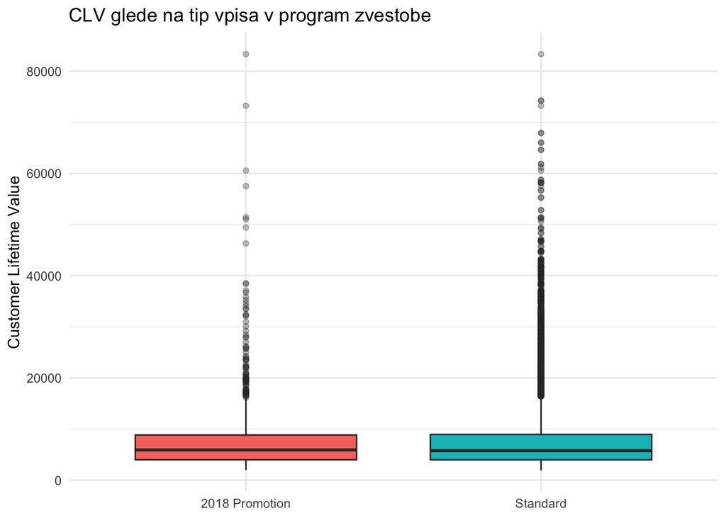

```r
## -------------------------------------------------------------------------
## 6. VIZUALIZACIJE
## -------------------------------------------------------------------------

# 6a. Distribucija CLV po enrollment tipu (boxplot - primerjava skupin, robusten na osamelce)
ggplot(df, aes(x = `Enrollment Type`, y = CLV, fill = `Enrollment Type`)) +
  geom_boxplot(outlier.alpha = 0.3) +
  labs(title = "CLV glede na tip vpisa v program zvestobe",
       y = "Customer Lifetime Value", x = NULL) +
  theme_minimal() +
  theme(legend.position = "none")
```

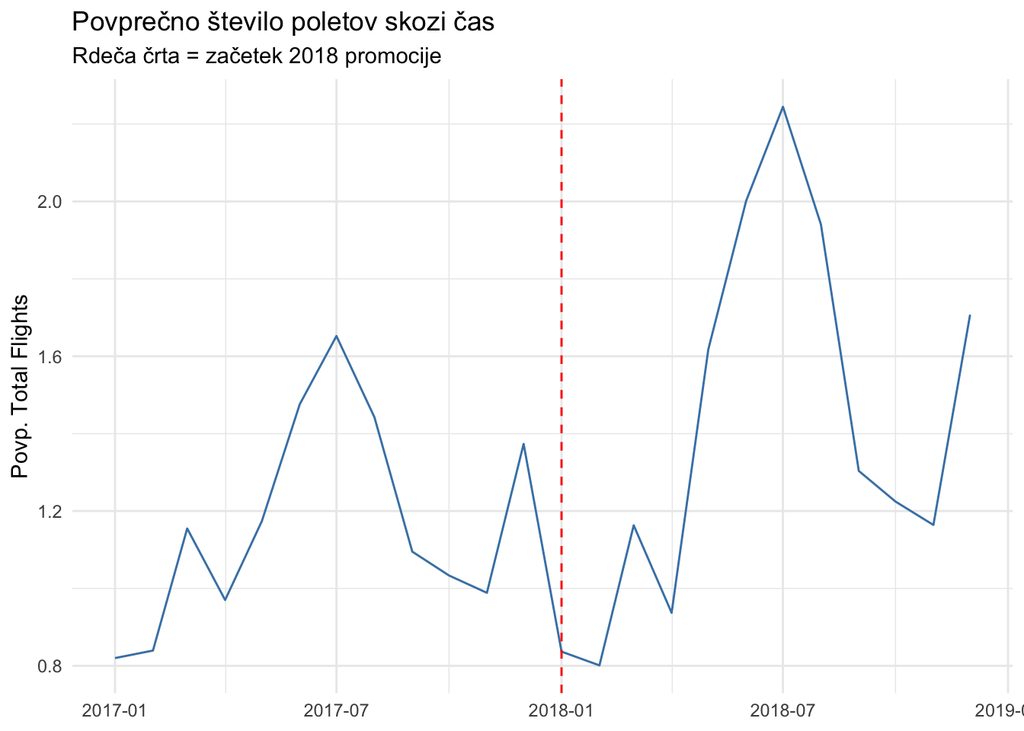

```r
# 6b. Časovna vrsta: povprečno število poletov na mesec po letih (učinek promocije v času)
Customer_Flight_Activity %>%
  group_by(Year, Month) %>%
  summarise(povp_flights = mean(`Total Flights`, na.rm = TRUE), .groups = "drop") %>%
  mutate(date = make_date(Year, Month, 1)) %>%
  ggplot(aes(x = date, y = povp_flights)) +
  geom_line(color = "steelblue") +
  geom_vline(xintercept = as.numeric(make_date(2018, 1, 1)),
             linetype = "dashed", color = "red") +
  labs(title = "Povprečno število poletov skozi čas",
       subtitle = "Rdeča črta = začetek 2018 promocije",
       x = NULL, y = "Povp. Total Flights") +
  theme_minimal()
```

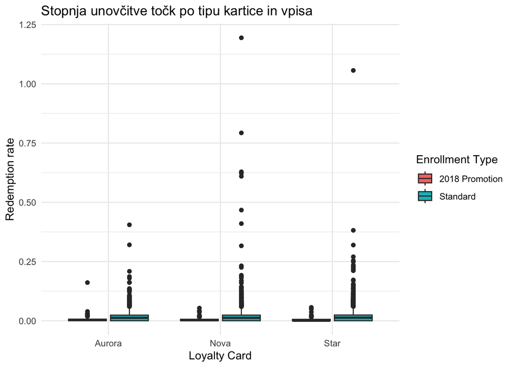

```r
# 6c. Redemption rate po tipu kartice in enrollment tipu
ggplot(df, aes(x = `Loyalty Card`, y = redemption_rate, fill = `Enrollment Type`)) +
  geom_boxplot() +
  labs(title = "Stopnja unovčitve točk po tipu kartice in vpisa",
       y = "Redemption rate", x = "Loyalty Card") +
  theme_minimal()
```

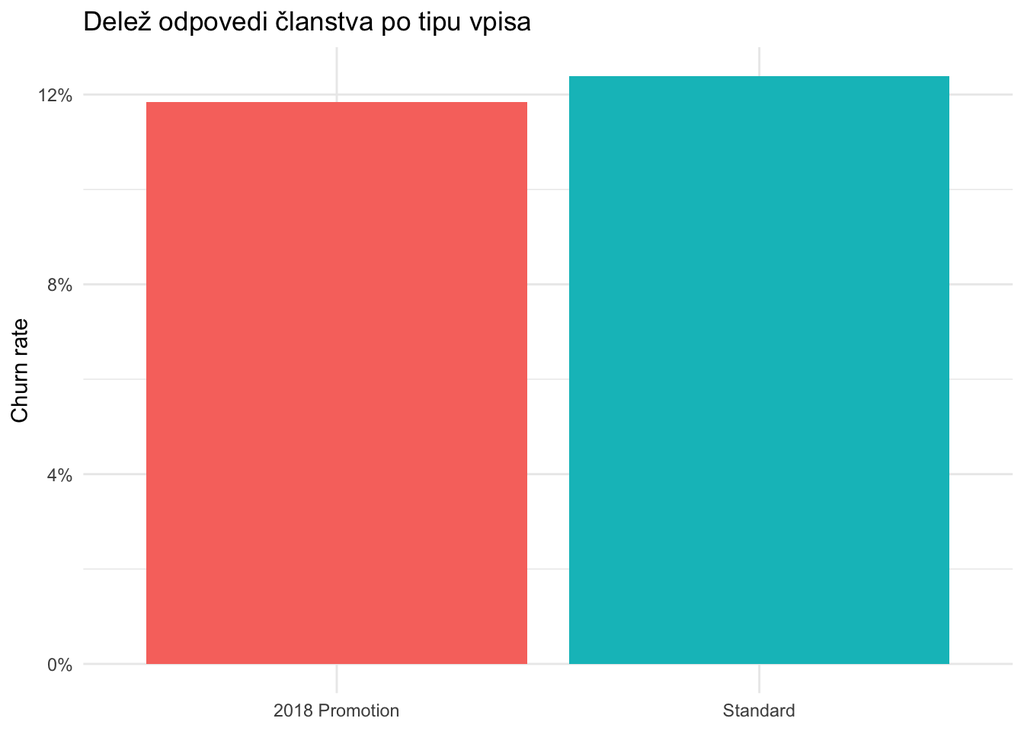

```r
# 6d. Churn rate po enrollment tipu (bar chart - deleži)
df %>%
  group_by(`Enrollment Type`) %>%
  summarise(churn_rate = mean(churned)) %>%
  ggplot(aes(x = `Enrollment Type`, y = churn_rate, fill = `Enrollment Type`)) +
  geom_col() +
  scale_y_continuous(labels = scales::percent) +
  labs(title = "Delež odpovedi članstva po tipu vpisa", y = "Churn rate", x = NULL) +
  theme_minimal() +
  theme(legend.position = "none")
```

# (Tristan) Identificirajte segmente strank z visoko vrednostjo in predlagajte možne ukrepe za optimizacijo

# (Patricija) Napovedovanje odliva strank oziroma odpovedi ter predlaganje možnih ukrepov za njihovo zadržanje